[figure not shown]

# **Exploring and Analyzing Music in a Decade of COVID-19 and TikTok**

> Puja Terse, Grace Zhang, and Aidan Borsh

# **1. Introduction:**

Music has stayed relatively constant in our lives, and it surrounds us during different moments. We use it to push us to the limits during an intense workout, help us focus while studying in the library till 2am, and we even use music to let loose while partying with our friends! During happy, sad, celebratory and other moments in our lives, music has stayed by our side.

On March 11, 2020, WHO (World Health Organization) declared COVID-19 a global pandemic. A majority of our lives changed from this point on such as switching to virtual school, following a stay at home order, closing down indoor seating in restaurants, wearing masks and staying 6 feet apart from friends. With such a huge change in our lives, we wanted to study the impact of COVID-19 on music, and see if the top 2020 songs had any distinct features compared to the top songs of 2010-2019. Since COVID-19 is still occurring in our lives today, we will be studying the top songs pre-COVID-19 and during/the peak of COVID-19.

Along with many new rules and changes to what our “normal” looked like, there was one app that started to change our lives as well. That app was TikTok. TikTok is an app where people can post 30 second to 1 minute videos about anything the user wants to post. We believe Tik Tok impacted the music/top songs of 2020 since many songs go viral if someone choreographs catchy dance moves to a portion of a song. This is how some artists become very popular and sometimes get discovered! One example is Doja Cat’s song “Say So” where she even included the catchy TikTok dance in her official music video. Along with our assumptions that TikTok played an important role for the top songs of 2020, we also want to analyze the features of popular TikTok songs vs the top songs of 2010-2020.

**What we will analyze:**

- Top Songs of 2010-2019 vs. Top Songs of 2020 (impact of COVID-19)
- TikTok Songs vs Top Songs of 2020
- Track properties of popular songs

# **Required Tools/Libraries:**

```python
import pandas as pd
import numpy as np
import matplotlib.pyplot as plt
from collections import Counter
import statsmodels.formula.api as smf
import seaborn as sns
```

# **2. Data Collection & Processing**

**Obtaining Data:**  
The top songs of 2020 data was obtained from [Organize Your Music](http://organizeyourmusic.playlistmachinery.com/#) using this Spotify [Tops Songs of 2020 Playlist](https://open.spotify.com/playlist/37i9dQZF1DXaqCgtv7ZR3L). The top songs of 2010-2019 data were used from this [Kaggle dataset](https://www.kaggle.com/leonardopena/top-spotify-songs-from-20102019-by-year). The top TikTok songs was also obtained from [Organize Your Music](http://organizeyourmusic.playlistmachinery.com/#), but using this Spotify [Tik Tok Songs](https://open.spotify.com/playlist/65LdqYCLcsV0lJoxpeQ6fW). The website Organize Your Music is super cool since it is linked to your Spotify account where you can analyze your own Spotify playlists. Moreover, you can find a specific Spotify playlist’s URI (here’s a Spotify [playlist to URI converter](https://www.spotifycodes.com/#create) that helped us) and analyze that playlist, which is what we did. This website already produced the following properties for each song on the playlist.

- **Genre** - the genre of the track
- **Year** - the release year of the recording.
- **Added** - the earliest date you added the track to your collection.
- **Beats Per Minute (BPM)** - The tempo of the song.
- **Energy** - The energy of a song - the higher the value, the more energetic. song
- **Danceability** - The higher the value, the easier it is to dance to this song.
- **Loudness (dB)** - The higher the value, the louder the song.
- **Liveness** - The higher the value, the more likely the song is a live recording.
- **Valence** - The higher the value, the more positive mood for the song.
- **Length** - The duration of the song.
- **Acousticness** - The higher the value the more acoustic the song is.
- **Speechiness** - The higher the value the more spoken word the song contains.
- **Popularity** - The higher the value the more popular the song is.

**Tidying the Data:**

The “year added” column of our data was not accurate since this date was the date I added the playlist to my Spotify account, so we removed this column. We also made sure all the column names for the datasets were the same. The dataset we first imported is the tops songs of 2010-2019, then we imported the top songs of 2020, and lastly we imported the top TikTok songs. We also created a dataset that combined the top songs of 2010-2019 and 2020, so we have a dataset that will carry the top songs of 2010-2020.

- top_10s = top songs of 2010-2019
- top_2020 = top songs of 2020
- tiktok = the top Tik Tok songs
- top_all = top songs of 2010-2020

```python
import pandas as pd
import numpy as np
import matplotlib.pyplot as plt

#create dataframe containing the Top Songs of 2010-2019 information
top_10s = pd.read_csv("top10s.csv", sep=",", encoding='mac_roman')
#remove unused column
top_10s = top_10s.drop('Unnamed: 0', axis = 1)
#show the first 5 songs
top_10s.head()
```

|  | title | artist | top genre | year | bpm | nrgy | dnce | dB | live | val | dur | acous | spch | pop |
| --- | --- | --- | --- | --- | --- | --- | --- | --- | --- | --- | --- | --- | --- | --- |
| 0 | Hey, Soul Sister | Train | neo mellow | 2010 | 97 | 89 | 67 | -4 | 8 | 80 | 217 | 19 | 4 | 83 |
| 1 | Love The Way You Lie | Eminem | detroit hip hop | 2010 | 87 | 93 | 75 | -5 | 52 | 64 | 263 | 24 | 23 | 82 |
| 2 | TiK ToK | Kesha | dance pop | 2010 | 120 | 84 | 76 | -3 | 29 | 71 | 200 | 10 | 14 | 80 |
| 3 | Bad Romance | Lady Gaga | dance pop | 2010 | 119 | 92 | 70 | -4 | 8 | 71 | 295 | 0 | 4 | 79 |
| 4 | Just the Way You Are | Bruno Mars | pop | 2010 | 109 | 84 | 64 | -5 | 9 | 43 | 221 | 2 | 4 | 78 |

```python
#create dataframe containing the Top Songs of 2020
top_2020 = pd.read_csv("top2020.csv", sep=",", encoding='mac_roman')
top_2020.head()
```

|  | title | artist | top genre | year | bpm | nrgy | dnce | dB | live | val | dur | acous | spch | pop |
| --- | --- | --- | --- | --- | --- | --- | --- | --- | --- | --- | --- | --- | --- | --- |
| 0 | Blinding Lights | The Weeknd | canadian contemporary r&b | 2020 | 171 | 73 | 51 | -6 | 9 | 33 | 200 | 0 | 6 | 94 |
| 1 | Watermelon Sugar | Harry Styles | pop | 2019 | 95 | 82 | 55 | -4 | 34 | 56 | 174 | 12 | 5 | 90 |
| 2 | ROCKSTAR (feat. Roddy Ricch) | DaBaby | north carolina hip hop | 2020 | 90 | 69 | 75 | -8 | 10 | 50 | 182 | 25 | 16 | 89 |
| 3 | Someone You Loved | Lewis Capaldi | pop | 2019 | 110 | 41 | 50 | -6 | 11 | 45 | 182 | 75 | 3 | 89 |
| 4 | Circles | Post Malone | dfw rap | 2019 | 120 | 76 | 70 | -3 | 9 | 55 | 215 | 19 | 4 | 88 |

```python
#merge the Top Songs of 2020 and Top Songs of 2010-2019, to have the Top Songs of 2010-2020
top_all = result = pd.concat([top_10s, top_2020])
top_all.head()
```

|  | title | artist | top genre | year | bpm | nrgy | dnce | dB | live | val | dur | acous | spch | pop |
| --- | --- | --- | --- | --- | --- | --- | --- | --- | --- | --- | --- | --- | --- | --- |
| 0 | Hey, Soul Sister | Train | neo mellow | 2010 | 97 | 89 | 67 | -4 | 8 | 80 | 217 | 19 | 4 | 83 |
| 1 | Love The Way You Lie | Eminem | detroit hip hop | 2010 | 87 | 93 | 75 | -5 | 52 | 64 | 263 | 24 | 23 | 82 |
| 2 | TiK ToK | Kesha | dance pop | 2010 | 120 | 84 | 76 | -3 | 29 | 71 | 200 | 10 | 14 | 80 |
| 3 | Bad Romance | Lady Gaga | dance pop | 2010 | 119 | 92 | 70 | -4 | 8 | 71 | 295 | 0 | 4 | 79 |
| 4 | Just the Way You Are | Bruno Mars | pop | 2010 | 109 | 84 | 64 | -5 | 9 | 43 | 221 | 2 | 4 | 78 |

```python
#create dataframe containing the Top TikTok Songs
tiktok = pd.read_csv("tiktok.csv", sep=",", encoding='mac_roman')
#rename the coloumn heads so they match the other dataframe's so it's easier to manipulate later on
tiktok.columns = ['title', 'artist', 'top genre', 'year', 'bpm', 'nrgy', 'dnce', 'dB','live','val','dur','acous','spch','pop']
tiktok.head()
```

|  | title | artist | top genre | year | bpm | nrgy | dnce | dB | live | val | dur | acous | spch | pop |
| --- | --- | --- | --- | --- | --- | --- | --- | --- | --- | --- | --- | --- | --- | --- |
| 0 | Peaches (feat. Daniel Caesar & Giveon) | Justin Bieber | canadian pop | 2021 | 90 | 70 | 68 | -6 | 42 | 46 | 198 | 32 | 12 | 100 |
| 1 | MONTERO (Call Me By Your Name) | Lil Nas X | country rap | 2021 | 179 | 51 | 61 | -7 | 38 | 76 | 138 | 30 | 15 | 99 |
| 2 | Astronaut In The Ocean | Masked Wolf | australian hip hop | 2021 | 150 | 70 | 78 | -7 | 15 | 47 | 133 | 18 | 9 | 97 |
| 3 | Kiss Me More (feat. SZA) | Doja Cat | dance pop | 2021 | 111 | 70 | 76 | -4 | 12 | 74 | 209 | 24 | 3 | 97 |
| 4 | Leave The Door Open | Bruno Mars | dance pop | 2021 | 148 | 62 | 59 | -8 | 9 | 72 | 242 | 18 | 3 | 96 |

# **3. Exploratory Data Analysis**

# 3A: Visualizing Change in Track Properties from 2010 to 2020

First let's take a look at how the track properties we identified have changed in the top songs throughout the last decade using the Top Songs of 2010-2019 and the Top Songs of 2020. Because the data only provides the year each song was created, we'll take the average value for each track property for each year. Then we will create a line graph for each track property using our averages.

```python
#find the average value of each track property for each year
top_decade = top_all.copy()

track_properties = ['bpm','nrgy', 'dnce', 'dB',
                     'live', 'val', 'dur', 'acous', 'spch']

property_avgs = top_decade.groupby(["year"])[track_properties].mean()
property_avgs.reset_index(inplace=True)
```

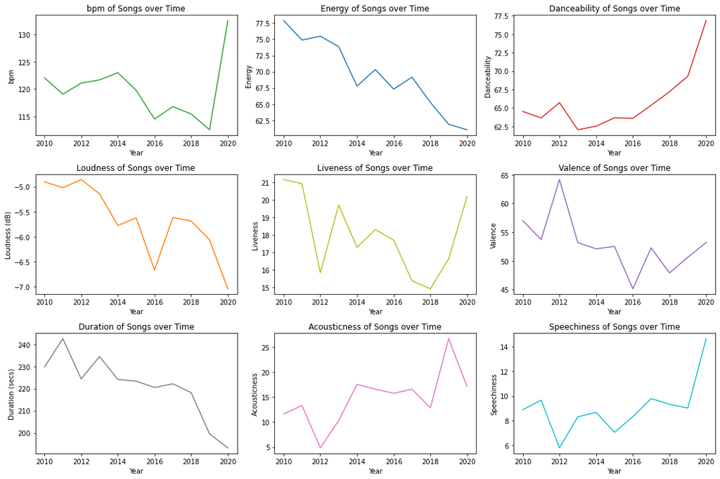

```python
# create plots
fig, axs = plt.subplots(3, 3, figsize=(15,10))

x = property_avgs['year']

#plot bpm
axs[0, 0].plot(x, property_avgs['bpm'], 'tab:green')
axs[0, 0].set_title("bpm of Songs over Time")
axs[0, 0].set(ylabel='bpm')

#plot energy
axs[0, 1].plot(x, property_avgs['nrgy'], 'tab:blue')
axs[0, 1].set_title("Energy of Songs over Time")
axs[0, 1].set(ylabel='Energy')

#plot danceability
axs[0, 2].plot(x, property_avgs['dnce'],  'tab:red')
axs[0, 2].set_title("Danceability of Songs over Time")
axs[0, 2].set(ylabel='Danceability')

#plot loudness
axs[1, 0].plot(x, property_avgs['dB'], 'tab:orange')
axs[1, 0].set_title("Loudness of Songs over Time")
axs[1, 0].set(ylabel='Loudness (dB)')

#plot liveness
axs[1, 1].plot(x, property_avgs['live'], 'tab:olive')
axs[1, 1].set_title("Liveness of Songs over Time")
axs[1, 1].set(ylabel='Liveness')

#plot valence
axs[1, 2].plot(x, property_avgs['val'], 'tab:purple')
axs[1, 2].set_title("Valence of Songs over Time")
axs[1, 2].set(ylabel='Valence')

#plot duration
axs[2, 0].plot(x, property_avgs['dur'], 'tab:grey')
axs[2, 0].set_title("Duration of Songs over Time")
axs[2, 0].set(ylabel='Duration (secs)')

#plot acousticness
axs[2, 1].plot(x, property_avgs['acous'], 'tab:pink')
axs[2, 1].set_title("Acousticness of Songs over Time")
axs[2, 1].set(ylabel='Acousticness')

#plot speechiness
axs[2, 2].plot(x, property_avgs['spch'], 'tab:cyan')
axs[2, 2].set_title("Speechiness of Songs over Time")
axs[2, 2].set(ylabel='Speechiness')


#set all x axis labels to Year
for ax in axs.flat:
    ax.set(xlabel='Year')

fig.tight_layout()
```

From this we can analyze the general trends of track properties during the 2010-2020 decade, giving us a larger scope that also reveals some of the impacts of COVID-19 on music popularity.

First, let's take a look at some of the track properties that trended downward over the past decade:

- **Energy** - Energy progressively decreased from 2010-2020. As a measure of intensity and activity, a decrease in energy indicates that other elements of songs are just as important in catching the listener's attention. In addition, lower energy songs may resonate with listeners more in general as streaming services make music available at any time of day, in any situation. People may stream music while brewing their morning cup of coffee, but that doesn't mean they want to start their day with the most intense and high-energy sounds.
- **Loudness (dB)** - Loudness is another factor that decreased from 2010-2020, however the scale indicates that the change from the 2010 average to the 2020 average was only ~2dB.
- **Length** - Song length has experienced a steady decline over the last decade, with top songs once averaging ~4 minutes dropping to average ~3 minutes. From a production perspective, this could indicate that popular music is likely condensed to contain a strong hook or chorus to catch the attention of the listener, or rather shorter songs are more likely to keep the listener's attention for the entire duration.

Next, let's take a look at some of the track properties that trended upward over the past decade:

- **Danceability** - Danceability had the most consistent upward trend across the decade compared to the other track properties. As our analysis includes a discussion of TikTok's influence on music popularity, it may stand to reason that 2020's most popular tracks were also most suitable for the latest TikTok dances going viral!
- **Acousticness** - Acousticness is another measure that increased over the past decade. An increase in acoustic presence may mean that music is regaining its balance from the highly produced and synthesized sounds of the early 2010s.
- **Speechiness** - The general increase of speechiness throughout the decade indicates that songs popular songs include a higher percentage of lyrics rather than instrumentals. From a genre perspective, this may indicate the rise of rap in popular music and even the inclusion of rap in other genres such as pop and country to create sub-genres that are higher in speechiness compared to their umbrella genres.
- **Beats Per Minute (BPM)** - The average tempo of top songs decreased from 2010-2019, but saw a sharp increase in 2020. This sharp increase is noteworthy, as our analysis is using the year 2020 to mark the presence of the COVID-19 pandemic. In some behavioral studies on music's affect on mood, mood-lifting songs had high BPMs. From this perspective, this may indicate higher BPMs had a signficant effect on the popular music of 2020.

Finally, let's look at two track properties without strong trends:

- **Liveness** - Liveness does not have a strong discernable pattern based on the above graph alone. As a measure of the likeliness a song is a live recording, liveness varies across popular songs each year.
- **Valence** - As a quantiative measure of mood, it is reasonable that valence averaged differently each year without a strong pattern that can be assessed visually. Although the above graph reveals a downward trend from 2012-2016, recent years indicate that the average valence of popular songs is trending upwards.

# 3B: Visualizing Track Properties between Top Songs of 2010-2019, Top Songs of 2020, and Top TikTok Songs

To start comparing the track properties of the Top Songs of 2010-2019, the Top Songs of 2020, and the Top TikTok songs, we wanted to easily visulize this information. Thus, we decided to create violin plots of each track property and have each dataset side by side to see the similarities and differences! The 2010-2019 violin plot will be on the left, the TikTok dataset will be in the center, and the 2020 will be on the right side.

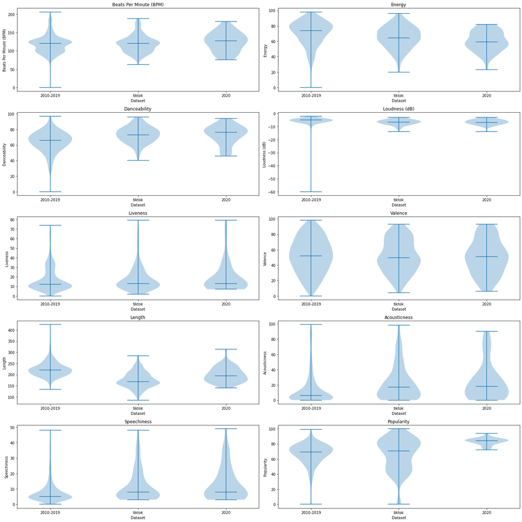

```python
#storing Track Properties from top songs of 2010-2019, tiktok, and 2020 data in different arrays
#categorized by their track property
bpm = [top_10s["bpm"], tiktok["bpm"], top_2020["bpm"]]
nrgy = [top_10s["nrgy"], tiktok["nrgy"], top_2020["nrgy"]]
dnce = [top_10s["dnce"], tiktok["dnce"], top_2020["dnce"]]
dB = [top_10s["dB"], tiktok["dB"], top_2020["dB"]]
live = [top_10s["live"], tiktok["live"], top_2020["live"]]
val = [top_10s["val"], tiktok["val"], top_2020["val"]]
dur = [top_10s["dur"], tiktok["dur"], top_2020["dur"]]
acous = [top_10s["acous"], tiktok["acous"], top_2020["acous"]]
spch = [top_10s["spch"], tiktok["spch"], top_2020["spch"]]
pop = [top_10s["pop"], tiktok["pop"], top_2020["pop"]]

#to make it easier to compare each plot from each property, let's layer the plots under and next to each other
#in a 5x2 grid pattern
fig, axs = plt.subplots(5, 2, figsize=(20,20))


#Violin Plot on the 3 different set's Beats Per Minute (BPM)
axs[0, 0].violinplot(bpm, showmeans=False, showmedians=True)
axs[0, 0].set_title('Beats Per Minute (BPM)')
axs[0, 0].set(ylabel='Beats Per Minute (BPM)')

#Violin Plot on the 3 different set's Energy
axs[0, 1].violinplot(nrgy, showmeans=False, showmedians=True)
axs[0, 1].set_title('Energy')
axs[0, 1].set(ylabel='Energy')

#Violin Plot on the 3 different set's Danceability
axs[1, 0].violinplot(dnce, showmeans=False, showmedians=True)
axs[1, 0].set_title('Danceability')
axs[1, 0].set(ylabel='Danceability')

#Violin Plot on the 3 different set's Loudness (dB)
axs[1, 1].violinplot(dB, showmeans=False, showmedians=True)
axs[1, 1].set_title('Loudness (dB)')
axs[1, 1].set(ylabel='Loudness (dB)')

#Violin Plot on the 3 different set's Liveness
axs[2, 0].violinplot(live, showmeans=False, showmedians=True)
axs[2, 0].set_title('Liveness')
axs[2, 0].set(ylabel='Liveness')

#Violin Plot on the 3 different set's Valence
axs[2, 1].violinplot(val, showmeans=False, showmedians=True)
axs[2, 1].set_title('Valence')
axs[2, 1].set(ylabel='Valence')

#Violin Plot on the 3 different set's Length
axs[3, 0].violinplot(dur, showmeans=False, showmedians=True)
axs[3, 0].set_title('Length')
axs[3, 0].set(ylabel='Length')

#Violin Plot on the 3 different set's Acousticness
axs[3, 1].violinplot(acous, showmeans=False, showmedians=True)
axs[3, 1].set_title('Acousticness')
axs[3, 1].set(ylabel='Acousticness')

#Violin Plot on the 3 different set's Speechiness
axs[4, 0].violinplot(spch, showmeans=False, showmedians=True)
axs[4, 0].set_title('Speechiness')
axs[4, 0].set(ylabel='Speechiness')

#Violin Plot on the 3 different set's Popularity
axs[4, 1].violinplot(pop, showmeans=False, showmedians=True)
axs[4, 1].set_title('Popularity')
axs[4, 1].set(ylabel='Popularity')

#labeling the violin plot so we know the one on the left correlates to the the top2010-2019,
#the center is top tik tok songs, and the right is the top 2020 songs
xticklabels = ['2010-2019', 'tiktok', '2020']
for ax in axs.flat:
    ax.set_xticks([1,2,3])
    ax.set_xticklabels(xticklabels)

#set all x axis labels to Dataset
for ax in axs.flat:
    ax.set(xlabel='Dataset')


plt.tight_layout()
```

**BPM**: After plotting the violin plot for the Beats per Minute (BPM) of the 3 datasets, we can see that the mean for the 2010-2019, TikTok, and 2020 dataset are really similar. The 2010-2019 dataset has a larger range, and all the datasets has a large bulby part around the mean.

**Energy**: Surprisingly, the 2010-2019 had the highest mean for energy compared to TikTok and the 2020 datasets. We expected TikTok to have the highest energy average since we believed TikTok-ers dance to high energy music. Also it looks like the Top Songs of 2020 had the lowest average enery, which can mean that maybe because of COVID-19 people perferred to listen to low energy music.

**Danceability:** Another surprise is that the 2020 dataset had the highest average of dancebility, with TikTok dataset coming in close. The 2010-2019 dataset again had a large range compared to the other datasets. The 2020 dataset having the highest average for danceability is suprising since it had the lowest average for energy. It seems like people during COVID-19 listend to a lot of songs they can dance to. For all three datasets, the main bulby part is around the mean.

**Loudness:** Again, the 2010-2019 dataset had a large range. However, it looks like all three datasets have a really close average for loudness, and the main buly part of the plot is around the average.

**Liveness:** All three datasets have a large range for liveness, and similar averages. It looks like there were not too many songs in the datasets that were a live recording, sine the averages are around 10. The 2010-2019 dataset is more bimodal compared to the other two datasets.

**Valence:** Valance had a large range for all three datasets. Also, all the averages were similar for the three datasets. The 2010-2019 dataset is more unimodal than the other two datasets. The TikTok and 2020 datasets look the most similar and are slightly bimodal. It is surprising that the TikTok and 2020 dataset have the same average as the 2010-2019 dataset. We expected the songs in the TikTok and 2020 datasets to have a higher valence average since a higher valence correlates to a more positive mood. So we thought becuase of COVID-19 people would want to listen to songs with more positive moods. For TikTok we thought people would want to dance to music with positive moods.

**Acousticness** The 2010-2019 dataset and TikTok dataset had similar ranges. The TikTok dataset looks more similar to the 2020 dataset since they have similar averages, but the 2020 dataset is more bimodal looking than the TikTok one. The average for the 2010-2019 dataset was lower than the other two datasets.

**Speechiness:** The averages for the TikTok and 2020 datasets were really similar, and the 2010-2019 dataset was a bit lower. All three datasets had a large range. The TikTok dataset looks pretty similar to the 2020 dataset.

**Popularity:** The popularity of the 2020 dataset looks the most different compared to the other two datasets. The 2020 dataset has a smaller range only between ~70 to ~95. The TikTok and 2010-2019 range is a lot bigger from 0 to 100. The average of the TikTok and 2010-2019 dataset is really close, while the average of the 2020 dataset is higher than the others. It seems like most songs in the TikTok dataset are around 80 (where the main bubly part is), however there is still a large amount of songs around 40 (the second main bubly part). The 2010-2019 data is unimodal. We expected that the TikTok songs would have a lot of popular songs, but instead it had a great range of songs of different popularities. The 2020 dataset had a lot of songs of high popular value.

# 3C: Finding Top Genres of Top Songs of 2010-2019, Top Songs of 2020, and Top TikTok Songs

The data from the top song of 2010-2019, 2020, and top TikTok songs contains a top genre column. We wanted to compare the genres of the 3 datasets and see what the most frequent genre is for each dataset and if there were any similarities. We were wondering if because of COVID-19 or TikTok that the top songs of 2020 most popular genre will be the same as the TikTok songs popular genre, or if it might be a different genre competely. The best way to easily visualize which genre appeared the most in each dataset is by creating a bar graph.

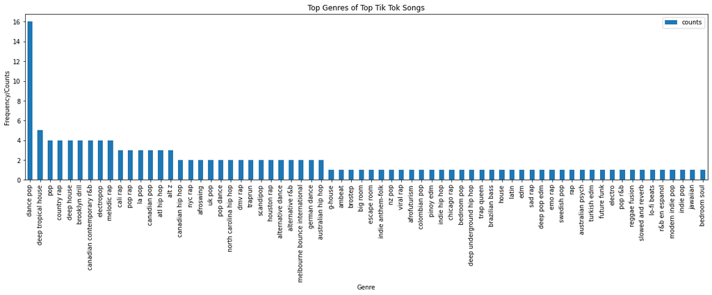

```python
import pandas as pd
import matplotlib.pyplot as plt
from collections import Counter
%matplotlib inline

plt.rcParams['figure.figsize'] = [20, 5]
#create a new dataframe so we don't mess up the original tiktok table
tiktok_df = tiktok
#count all the occurances of repeated genres
tiktok_df['top genre'].value_counts()
#create a new column to hold the counts of each genre
tiktok_df = tiktok_df['top genre'].value_counts().rename_axis('unique_values').reset_index(name='counts')
#plot the number of times a genre appeared vs. the genre name
tiktok_df.plot(x="unique_values", y="counts", kind="bar", title="Top Genres of Top Tik Tok Songs", xlabel = 'Genre', ylabel='Frequency/Counts')
```

After handling our data and making a bar graph of the genres that appeared in the top TikTok song dataset vs its frequency, we can see that the most frequent genre is Dance Pop. This isn't too surprising since many TikTok-ers like to choreograph to popular music.

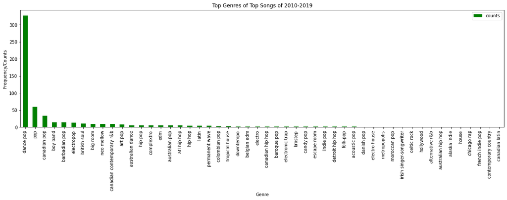

```python
plt.rcParams['figure.figsize'] = [20, 5]
#create a new dataframe so we don't mess up the original top 2010-2019 dataframe
top10s_df = top_10s
#count all the occurances of repeated genres
top10s_df['top genre'].value_counts()
#create a new column to hold the counts of each genre
top10s_df = top10s_df['top genre'].value_counts().rename_axis('unique_values').reset_index(name='counts')
#plot the number of times a genre appeared vs. the genre name
top10s_df.plot(x="unique_values", y="counts", kind="bar", title="Top Genres of Top Songs of 2010-2019", xlabel = 'Genre', ylabel='Frequency/Counts', color="green")
```

Next, we created a bar graph of the genres that appeared in the Top Songs of 2010-2019 dataset and plotted it against the genre's frequency. The most popular genre of 2010-2019 was also Dance Pop like the TikTok dataset.

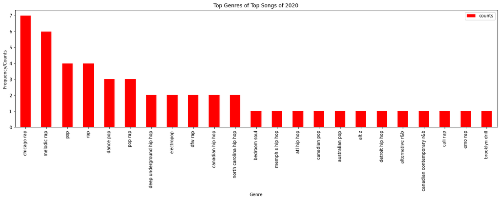

```python
plt.rcParams['figure.figsize'] = [20, 5]
#create a new dataframe so we don't mess up the original top 2020 dataframe
top2020_df = top_2020
#count all the occurances of repeated genres
top2020_df['top genre'].value_counts()
#create a new column to hold the counts of each genre
top2020_df = top2020_df['top genre'].value_counts().rename_axis('unique_values').reset_index(name='counts')
#plot the number of times a genre appeared vs. the genre name
top2020_df.plot(x="unique_values", y="counts", kind="bar", title="Top Genres of Top Songs of 2020", xlabel = 'Genre', ylabel='Frequency/Counts', color="red")
```

Lastly, we created a bar graph for the Top Songs of 2020 dataset's top genres and plotted it against it's frequency. Surprisingly, the most frequent genre was not Dance Pop, but rather Chicago Rap. We got curious why this was the most frequently showing genre in the Top Songs of 2020 Spotify playlist, and after a little more research we discovered that there were many Juice WRLD songs in this playlist, and most of his music's genre is Chicago Rap. Since Juice WRLD sadly passed away in 2020, his death was a huge topic in the media. His fans wanted to show their support and streamed his songs a lot that year, which allowed his songs to get in the Top Songs of 2020 playlist.

After plotting all the dataset's genres, we also noticed that many genres had similar names or variations of other genres. For example, there is a genre called "Pop Dance" as well as "Dance Pop". Moreover, some genre names can be too specific or too vauge. For example, Rihanna's music genre is called "Barbadian Pop" and the Jonas Brother's music genre is called "Boy Bands". Since the most frequent showing top genre for both the TikTok dataset and Top Songs of 2010-2019 dataset was Dance Pop, we wanted to see which dataset had more occurrances of the "pop" genre. In other words we wanted to see which dataset contained the most genres that contained the word "pop".

```python
#creating an array to hold to word "pop"
words = ['pop']
#going through the tiktok dataset we created above for the bar graph, and going through the genre names
#if the genre name has the word "pop" in it we add 1 to the corresponding genre
tiktok_df = tiktok_df["unique_values"].str.extractall('({})'.format('|'.join(words))).iloc[:, 0].str.get_dummies().sum(level=0)
#sum will add all the rows that had the word "pop" in it
tiktok_df.sum()
```

```
pop    17
dtype: int64
```

```python
#same as above but for the top 2010-2019 dataset we created above for its bar graph
top10s_df = top10s_df["unique_values"].str.extractall('({})'.format('|'.join(words))).iloc[:, 0].str.get_dummies().sum(level=0)
top10s_df.sum()
```

```
pop    18
dtype: int64
```

# **4. Hypothesis Testing**

# 4A: Predicting Popularity with Other Track Properties

Now, we will use scatter plots and multiple linear regession (see "Resources" section below for more information) to test our hypothesis of whether or not any or all track properties (specifically- tempo (bpm), energy, danceability, loudness (dB), liveness, valence, duration, acousticness, and speechiness) are significant in predicting a song's popularity.

While we may also use other methods, such as the classification and regression tree (CART) model or multiple simple linear regression models to identify significant predictors, we choose to use multiple linear regression for its ease of interpretation and capacity to incorporate multiple variables at once.

To start out, we will plot each track property against song popularity for the songs between 2010 and 2020.

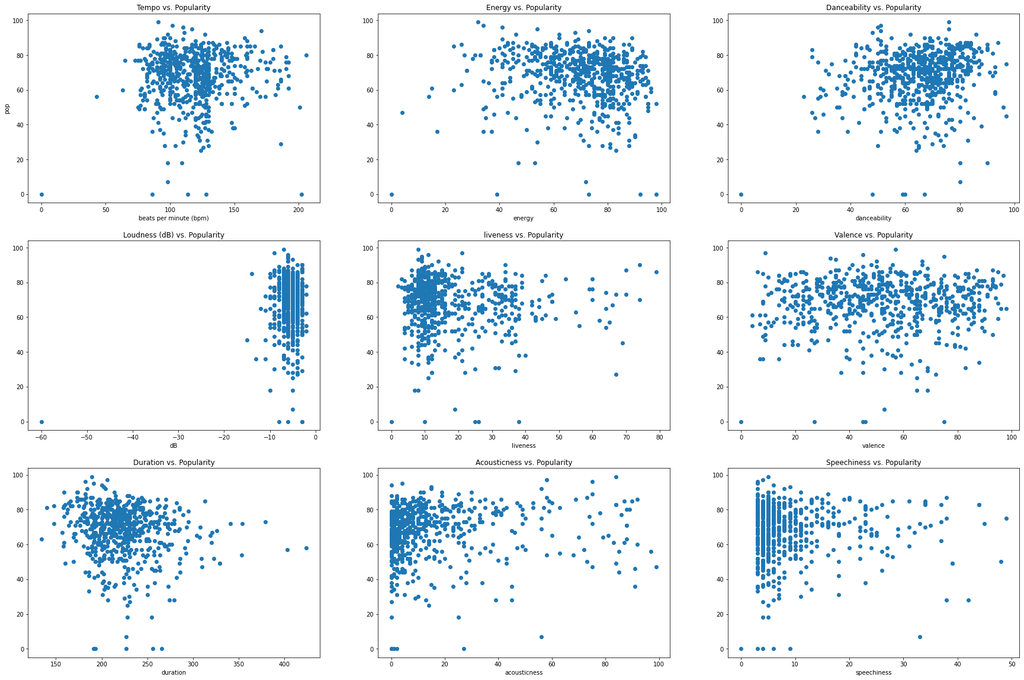

```python
fig, ax = plt.subplots(nrows=3, ncols=3, figsize=(30,20))

ax[0, 0].scatter(top_all['bpm'], top_all['pop'])
ax[0, 0].set_title('Tempo vs. Popularity')
ax[0, 0].set_xlabel('beats per minute (bpm)')
ax[0, 0].set_ylabel('pop')

ax[0, 1].scatter(top_all['nrgy'], top_all['pop'])
ax[0, 1].set_title('Energy vs. Popularity')
ax[0, 1].set_xlabel('energy')
ax[0, 0].set_ylabel('pop')

ax[0, 2].scatter(top_all['dnce'], top_all['pop'])
ax[0, 2].set_title('Danceability vs. Popularity')
ax[0, 2].set_xlabel('danceability')
ax[0, 0].set_ylabel('pop')

ax[1, 0].scatter(top_all['dB'], top_all['pop'])
ax[1, 0].set_title('Loudness (dB) vs. Popularity')
ax[1, 0].set_xlabel('dB')
ax[0, 0].set_ylabel('pop')

ax[1, 1].scatter(top_all['live'], top_all['pop'])
ax[1, 1].set_title('liveness vs. Popularity')
ax[1, 1].set_xlabel('liveness')
ax[0, 0].set_ylabel('pop')

ax[1, 2].scatter(top_all['val'], top_all['pop'])
ax[1, 2].set_title('Valence vs. Popularity')
ax[1, 2].set_xlabel('valence')
ax[0, 0].set_ylabel('pop')

ax[2, 0].scatter(top_all['dur'], top_all['pop'])
ax[2, 0].set_title('Duration vs. Popularity')
ax[2, 0].set_xlabel('duration')
ax[0, 0].set_ylabel('pop')

ax[2, 1].scatter(top_all['acous'], top_all['pop'])
ax[2, 1].set_title('Acousticness vs. Popularity')
ax[2, 1].set_xlabel('acousticness')
ax[0, 0].set_ylabel('pop')

ax[2, 2].scatter(top_all['spch'], top_all['pop'])
ax[2, 2].set_title('Speechiness vs. Popularity')
ax[2, 2].set_xlabel('speechiness')
ax[0, 0].set_ylabel('pop')

plt.show()
```

For the top songs from 2010 to 2020, we created scatter plots for each track property against Popularity. After creating the plots, we can see that there is likely little to no linear correlation between many track propoerties and Popularity. For example, for plots showing Loudness (dB) and Valence vs. Property, the same loudness correlates with a wide range of Popularity ratings, and a wide range of Valence values correlate with the same Popularity rating. However, for plots such as Danceability vs. Popularity, we can notice that on average, as the Danceability increases, the Popularity ratings also seem to increase. Additionally, for the plot of Duration and Energy vs. Popularity, as the Duration and Energy levels increase, on average, the Popularity ratings seem to decrease.

To analyze if this change is significant, we can run a multiple linear regression to find which track properties, if any, are significant in predicting the Popularity rating of a song. Our null hypothesis is that there is no relationship between other track properties of the table and Popularity, and our alternative hypothesis is that there is at least one track property variable that is significant in predicting song Popularity for songs from 2010 to 2020.

```python
#using smf to create the regression results of the plots above
mlm_all = smf.ols(formula='pop ~ bpm + nrgy + dnce + dB + live + val + dur + acous + spch', data = top_all).fit()
print(mlm_all.summary().tables[0])
print(mlm_all.summary().tables[1])
```

```
                            OLS Regression Results
==============================================================================
Dep. Variable:                    pop   R-squared:                       0.093
Model:                            OLS   Adj. R-squared:                  0.080
Method:                 Least Squares   F-statistic:                     7.275
Date:                Mon, 17 May 2021   Prob (F-statistic):           4.07e-10
Time:                        18:58:52   Log-Likelihood:                -2644.8
No. Observations:                 652   AIC:                             5310.
Df Residuals:                     642   BIC:                             5354.
Df Model:                           9
Covariance Type:            nonrobust
==============================================================================
==============================================================================
                 coef    std err          t      P>|t|      [0.025      0.975]
------------------------------------------------------------------------------
Intercept     92.1149      8.257     11.156      0.000      75.900     108.330
bpm            0.0217      0.023      0.939      0.348      -0.024       0.067
nrgy          -0.2158      0.053     -4.088      0.000      -0.319      -0.112
dnce           0.1432      0.050      2.892      0.004       0.046       0.240
dB             1.1879      0.253      4.703      0.000       0.692       1.684
live          -0.0278      0.042     -0.654      0.513      -0.111       0.056
val           -0.0296      0.031     -0.949      0.343      -0.091       0.032
dur           -0.0584      0.016     -3.541      0.000      -0.091      -0.026
acous         -0.0011      0.033     -0.032      0.975      -0.066       0.064
spch           0.0676      0.072      0.945      0.345      -0.073       0.208
==============================================================================
```

Now, we will use backwards elimination (see "Resources" section below for more information) until all predictors are significant at a 95% confidence level. To start off, we will remove "acous", the variable with the highest p-value, from the regression formula

```python
mlm_all = smf.ols(formula='pop ~ bpm + nrgy + dnce + dB + live + val + dur + spch', data = top_all).fit()
print(mlm_all.summary().tables[1])
```

```
==============================================================================
                 coef    std err          t      P>|t|      [0.025      0.975]
------------------------------------------------------------------------------
Intercept     91.9906      7.279     12.637      0.000      77.696     106.285
bpm            0.0218      0.023      0.953      0.341      -0.023       0.067
nrgy          -0.2149      0.044     -4.903      0.000      -0.301      -0.129
dnce           0.1436      0.048      2.990      0.003       0.049       0.238
dB             1.1863      0.247      4.803      0.000       0.701       1.671
live          -0.0278      0.042     -0.655      0.513      -0.111       0.056
val           -0.0297      0.031     -0.956      0.339      -0.091       0.031
dur           -0.0584      0.016     -3.544      0.000      -0.091      -0.026
spch           0.0675      0.071      0.946      0.344      -0.073       0.208
==============================================================================
```

Now, we remove "live"

```python
mlm_all = smf.ols(formula='pop ~ bpm + nrgy + dnce + dB + val + dur + spch', data = top_all).fit()
print(mlm_all.summary().tables[1])
```

```
==============================================================================
                 coef    std err          t      P>|t|      [0.025      0.975]
------------------------------------------------------------------------------
Intercept     92.1073      7.274     12.662      0.000      77.824     106.391
bpm            0.0209      0.023      0.916      0.360      -0.024       0.066
nrgy          -0.2193      0.043     -5.066      0.000      -0.304      -0.134
dnce           0.1435      0.048      2.989      0.003       0.049       0.238
dB             1.1905      0.247      4.824      0.000       0.706       1.675
val           -0.0289      0.031     -0.931      0.352      -0.090       0.032
dur           -0.0591      0.016     -3.600      0.000      -0.091      -0.027
spch           0.0626      0.071      0.883      0.377      -0.077       0.202
==============================================================================
```

```python
mlm_all = smf.ols(formula='pop ~ nrgy + dnce + dB + val + dur + spch', data = top_all).fit()
print(mlm_all.summary().tables[1])
```

```
==============================================================================
                 coef    std err          t      P>|t|      [0.025      0.975]
------------------------------------------------------------------------------
Intercept     95.2522      6.411     14.858      0.000      82.663     107.841
nrgy          -0.2187      0.043     -5.053      0.000      -0.304      -0.134
dnce           0.1373      0.048      2.889      0.004       0.044       0.231
dB             1.2262      0.244      5.032      0.000       0.748       1.705
val           -0.0289      0.031     -0.930      0.353      -0.090       0.032
dur           -0.0598      0.016     -3.647      0.000      -0.092      -0.028
spch           0.0689      0.071      0.977      0.329      -0.070       0.207
==============================================================================
```

Now, we remove "val"

```python
mlm_all = smf.ols(formula='pop ~ nrgy + dnce + dB + dur + spch', data = top_all).fit()
print(mlm_all.summary().tables[1])
```

```
==============================================================================
                 coef    std err          t      P>|t|      [0.025      0.975]
------------------------------------------------------------------------------
Intercept     95.4528      6.407     14.899      0.000      82.872     108.033
nrgy          -0.2316      0.041     -5.654      0.000      -0.312      -0.151
dnce           0.1174      0.042      2.768      0.006       0.034       0.201
dB             1.2228      0.244      5.019      0.000       0.744       1.701
dur           -0.0574      0.016     -3.545      0.000      -0.089      -0.026
spch           0.0614      0.070      0.877      0.381      -0.076       0.199
==============================================================================
```

Now, we remove "spch"

```python
mlm_all = smf.ols(formula='pop ~ nrgy + dnce + dB + dur', data = top_all).fit()
print(mlm_all.summary().tables[0])
print(mlm_all.summary().tables[1])
```

```
                            OLS Regression Results
==============================================================================
Dep. Variable:                    pop   R-squared:                       0.088
Model:                            OLS   Adj. R-squared:                  0.083
Method:                 Least Squares   F-statistic:                     15.70
Date:                Mon, 17 May 2021   Prob (F-statistic):           2.88e-12
Time:                        18:58:52   Log-Likelihood:                -2646.3
No. Observations:                 652   AIC:                             5303.
Df Residuals:                     647   BIC:                             5325.
Df Model:                           4
Covariance Type:            nonrobust
==============================================================================
==============================================================================
                 coef    std err          t      P>|t|      [0.025      0.975]
------------------------------------------------------------------------------
Intercept     95.4664      6.406     14.904      0.000      82.888     108.045
nrgy          -0.2281      0.041     -5.596      0.000      -0.308      -0.148
dnce           0.1186      0.042      2.799      0.005       0.035       0.202
dB             1.2081      0.243      4.971      0.000       0.731       1.685
dur           -0.0569      0.016     -3.516      0.000      -0.089      -0.025
==============================================================================
```

We can end backwards elimination here, as all variables have a p-value below 0.05. We see that on average, for the top songs from 2010 to 2020, as energy increases by 1, popularity decreases by 0.2281, as danceability increases by 1, popularity increases by 0.1186, as loudness increases by 1 dB, popularity increases by 1.2081, and as duration increases by 1, popularity decreases by 0.0569.

However, we must also note that the R-squared (0.088) and adjusted R-squared (0.083) values are still very low, so we know the model does not do well in explaining the extent of variation of song popularity against the remaining variables.

Additionally, the significant variables identified by the model are somewhat aligned with our predictions from the scatter plots-- we originally found that higher danceability is correlated with higher popularity and higher duration and energy are correlated with lower popularity. However, the model also found loudness (dB) to be a significant predictor of popularity, which we originally thought would not be predictor for a linear correlation. To examine this, we revisited the scatter plots, and we noticed that there is one outlier on the Loudness (dB) vs. Popularity graph that is at a very low dB and Popularity (whereas the rest are higher dB and a range of Popularity). Therefore, we believe this inclusion of dB in the final model may be due to the outlier.

Next, we will run the same models with scatter plots and multiple linear regression to test our original hypothesis on just the 2020 TikTok songs from our table.

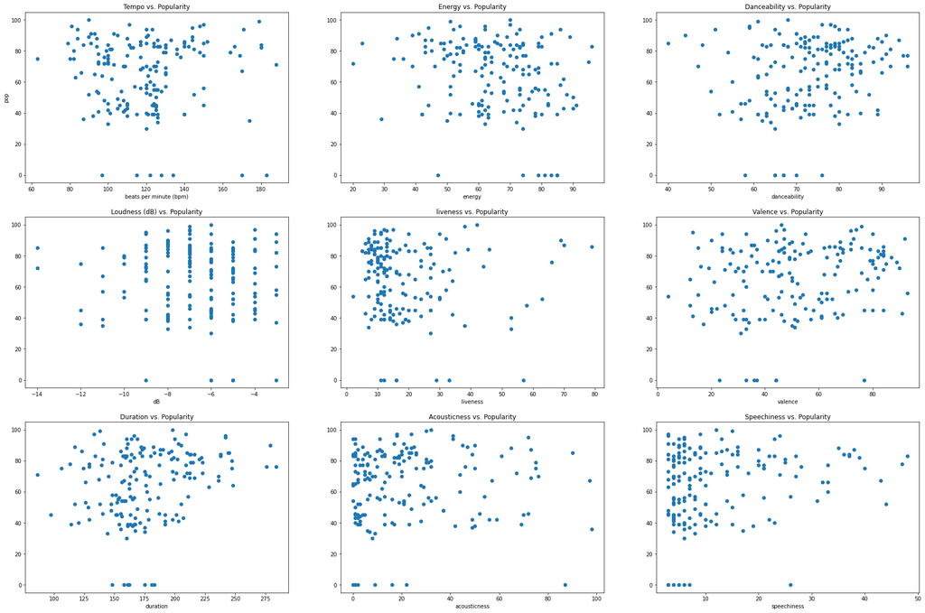

```python
fig, ax = plt.subplots(nrows=3, ncols=3, figsize=(30,20))

ax[0, 0].scatter(tiktok['bpm'], tiktok['pop'])
ax[0, 0].set_title('Tempo vs. Popularity')
ax[0, 0].set_xlabel('beats per minute (bpm)')
ax[0, 0].set_ylabel('pop')

ax[0, 1].scatter(tiktok['nrgy'], tiktok['pop'])
ax[0, 1].set_title('Energy vs. Popularity')
ax[0, 1].set_xlabel('energy')
ax[0, 0].set_ylabel('pop')

ax[0, 2].scatter(tiktok['dnce'], tiktok['pop'])
ax[0, 2].set_title('Danceability vs. Popularity')
ax[0, 2].set_xlabel('danceability')
ax[0, 0].set_ylabel('pop')

ax[1, 0].scatter(tiktok['dB'], tiktok['pop'])
ax[1, 0].set_title('Loudness (dB) vs. Popularity')
ax[1, 0].set_xlabel('dB')
ax[0, 0].set_ylabel('pop')

ax[1, 1].scatter(tiktok['live'], tiktok['pop'])
ax[1, 1].set_title('liveness vs. Popularity')
ax[1, 1].set_xlabel('liveness')
ax[0, 0].set_ylabel('pop')

ax[1, 2].scatter(tiktok['val'], tiktok['pop'])
ax[1, 2].set_title('Valence vs. Popularity')
ax[1, 2].set_xlabel('valence')
ax[0, 0].set_ylabel('pop')

ax[2, 0].scatter(tiktok['dur'], tiktok['pop'])
ax[2, 0].set_title('Duration vs. Popularity')
ax[2, 0].set_xlabel('duration')
ax[0, 0].set_ylabel('pop')

ax[2, 1].scatter(tiktok['acous'], tiktok['pop'])
ax[2, 1].set_title('Acousticness vs. Popularity')
ax[2, 1].set_xlabel('acousticness')
ax[0, 0].set_ylabel('pop')

ax[2, 2].scatter(tiktok['spch'], tiktok['pop'])
ax[2, 2].set_title('Speechiness vs. Popularity')
ax[2, 2].set_xlabel('speechiness')
ax[0, 0].set_ylabel('pop')

plt.show()
```

Initially, we cannot gather any insights on linear trends in the plots shown above. We will continue with multiple linear regression to test our hypothesis of whether or not there exists a track propoerty variable in the given table for top TikTok songs of 2020 that can predict the popularity of a song. Our null hypothesis, as before, is that there is no significant predictor, and our alternative hypothesis is that there is at least one predictor of of the track properties we have from our table that is linearly correlated with song popularity.

```python
mlm_tiktok = smf.ols(formula='pop ~ bpm + nrgy + dnce + dB + live + val + dur + acous + spch', data = tiktok).fit()
print(mlm_tiktok.summary().tables[0])
print(mlm_tiktok.summary().tables[1])
```

```
                            OLS Regression Results
==============================================================================
Dep. Variable:                    pop   R-squared:                       0.211
Model:                            OLS   Adj. R-squared:                  0.166
Method:                 Least Squares   F-statistic:                     4.747
Date:                Mon, 17 May 2021   Prob (F-statistic):           1.32e-05
Time:                        18:58:54   Log-Likelihood:                -751.13
No. Observations:                 170   AIC:                             1522.
Df Residuals:                     160   BIC:                             1554.
Df Model:                           9
Covariance Type:            nonrobust
==============================================================================
==============================================================================
                 coef    std err          t      P>|t|      [0.025      0.975]
------------------------------------------------------------------------------
Intercept     87.2742     31.129      2.804      0.006      25.797     148.752
bpm           -0.0063      0.070     -0.090      0.928      -0.145       0.133
nrgy          -0.6789      0.194     -3.497      0.001      -1.062      -0.295
dnce           0.0414      0.179      0.231      0.817      -0.312       0.395
dB             2.2275      1.222      1.823      0.070      -0.186       4.641
live          -0.0811      0.117     -0.692      0.490      -0.313       0.150
val            0.1874      0.086      2.186      0.030       0.018       0.357
dur            0.1376      0.047      2.955      0.004       0.046       0.230
acous         -0.0839      0.083     -1.007      0.316      -0.248       0.081
spch           0.3438      0.159      2.166      0.032       0.030       0.657
==============================================================================
```

Now, we remove "bpm"

```python
mlm_tiktok = smf.ols(formula='pop ~ nrgy + dnce + dB + live + val + dur + acous + spch', data = tiktok).fit()
print(mlm_tiktok.summary().tables[1])
```

```
==============================================================================
                 coef    std err          t      P>|t|      [0.025      0.975]
------------------------------------------------------------------------------
Intercept     86.3363     29.245      2.952      0.004      28.583     144.089
nrgy          -0.6792      0.194     -3.510      0.001      -1.061      -0.297
dnce           0.0430      0.177      0.243      0.809      -0.307       0.393
dB             2.2249      1.218      1.827      0.070      -0.180       4.630
live          -0.0812      0.117     -0.695      0.488      -0.312       0.150
val            0.1872      0.085      2.191      0.030       0.019       0.356
dur            0.1382      0.046      3.004      0.003       0.047       0.229
acous         -0.0835      0.083     -1.007      0.316      -0.247       0.080
spch           0.3410      0.155      2.198      0.029       0.035       0.647
==============================================================================
```

Now, we remove "dnce"

```python
mlm_tiktok = smf.ols(formula='pop ~ nrgy + dB + live + val + dur + acous + spch', data = tiktok).fit()
print(mlm_tiktok.summary().tables[1])
```

```
==============================================================================
                 coef    std err          t      P>|t|      [0.025      0.975]
------------------------------------------------------------------------------
Intercept     91.3174     20.763      4.398      0.000      50.317     132.318
nrgy          -0.6981      0.177     -3.954      0.000      -1.047      -0.349
dB             2.3119      1.160      1.992      0.048       0.020       4.603
live          -0.0837      0.116     -0.721      0.472      -0.313       0.145
val            0.1948      0.079      2.459      0.015       0.038       0.351
dur            0.1361      0.045      3.019      0.003       0.047       0.225
acous         -0.0871      0.081     -1.069      0.287      -0.248       0.074
spch           0.3464      0.153      2.263      0.025       0.044       0.649
==============================================================================
```

Now, we remove "live"

```python
mlm_tiktok = smf.ols(formula='pop ~ nrgy + dB + val + dur + acous + spch', data = tiktok).fit()
print(mlm_tiktok.summary().tables[1])
```

```
==============================================================================
                 coef    std err          t      P>|t|      [0.025      0.975]
------------------------------------------------------------------------------
Intercept     91.2177     20.732      4.400      0.000      50.281     132.155
nrgy          -0.7126      0.175     -4.068      0.000      -1.058      -0.367
dB             2.3646      1.156      2.045      0.042       0.081       4.648
val            0.1923      0.079      2.433      0.016       0.036       0.348
dur            0.1360      0.045      3.021      0.003       0.047       0.225
acous         -0.0915      0.081     -1.129      0.261      -0.252       0.069
spch           0.3538      0.153      2.320      0.022       0.053       0.655
==============================================================================
```

Now, we remove "acous"

```python
mlm_tiktok = smf.ols(formula='pop ~ nrgy + dB + val + dur + spch', data = tiktok).fit()
print(mlm_tiktok.summary().tables[1])
```

```
==============================================================================
                 coef    std err          t      P>|t|      [0.025      0.975]
------------------------------------------------------------------------------
Intercept     87.3995     20.471      4.269      0.000      46.979     127.820
nrgy          -0.6642      0.170     -3.908      0.000      -1.000      -0.329
dB             2.5401      1.147      2.215      0.028       0.276       4.805
val            0.2014      0.079      2.561      0.011       0.046       0.357
dur            0.1329      0.045      2.954      0.004       0.044       0.222
spch           0.3424      0.152      2.248      0.026       0.042       0.643
==============================================================================
```

From the summary output of the TikTok table after using Backwards Elimination, we notice that energy, loudness, valence, duration, and speechiness of songs are all significant predictors of 2020 TikTok song popularity (at a 95% confidence level). On average, for the TikTok songs in our table, as energy increases by 1, popularity decreases by 0.6642, as loudness increases by 1 dB, popularity increases by 2.5401, as valence increases by 1, popularity increases by 0.2014, as duration increases by 1, popularity increases by 0.1329, and as speechiness increases by 1, popularity increases by 0.3424.

Although we were unable to notice such trends from the initial scatter plots, we have several hypotheses for why each predictor may be significant in a real-world context, as personal users of TikTok.

Firstly, higher valence may be linearly correlated with higher popularity, as valence is defined as the positiveness and happiness of a song. In the current environment with the COVID-19 pandemic, many users are likely to seek and benefit from songs that uplift their mood, therefore causing such songs to become more popular.

Secondly, a longer duration may be linearly correlated with higher popularity, as a longer song is more likely to have a variety of components that could become viral on the TikTok platform.

Thirdly, a higher speechiness duration may be linearly correlated with higher popularity, as more words in a song could lead to more inspirations for viral TikTok trends such as dances and lip syncs.

However, more data would be needed to support our hypotheses.

In addition, after researching the Spotify API, we found that there are 3 main categories of songs: Mood, Properties, and Context, that are a combination of the track properties we analyzed, as shown:

Mood: Danceability, Valence, Energy, Tempo

Properties: Loudness, Speechiness, Instrumentalness

Context: Liveness, Acousticness

From both the 2010-2020 and TikTok tables, we found that energy was a significant predictor. Additionally, danceability was a significant predictor of popularity for 2010 to 2020 music, and valence and was a significant predictor of popularity for TikTok music. Therefore, we know that on average, the Mood of songs are a significant contributor to the popularity levels.

Furthermore, loudness (dB) was a significant predictor in both tables and speechiness was a significant predictor in the TikTok table as well, so we can conclude that on average, the Spotify Properties of a song are also significant contributors to its popularity.

# 4B: Predicting Song Energy, Danceability, and Duration over Time from 2010 to 2020

During our data exploration phase, we also plotted the various track properties over time, and we noticed several seemingly linear trends over time for some properties. Now, we will choose to look at the changes of Song Energy, Danceability, and Duration over time for the songs from 2010 to 2020, as these 3 properties seemed to have the most consistently linear trends between 2010 and 2020 and are also properties that we, as researchers, are interested in gaining more insights on.

We will first use a scatter plot with trend lines to test our hypothesis that each property is linearly correlated with time, and we will use linear regression to test our hypothesis.

First, we will look at a scatter plot of Song Energy over Time

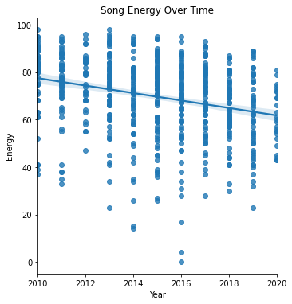

```python
sns.lmplot(x = 'year', y = 'nrgy', data = top_all)
plt.title("Song Energy Over Time")
plt.xlabel("Year")
plt.ylabel("Energy")
plt.show()
```

We can immediately notice a negative trend for song energy as time increases from 2010 to 2020. Now, we will use a linear regression to test this.

```python
lm_energy = smf.ols(formula='nrgy ~ year', data = top_all).fit()
print(lm_energy.summary().tables[0])
print(lm_energy.summary().tables[1])
```

```
                            OLS Regression Results
==============================================================================
Dep. Variable:                   nrgy   R-squared:                       0.073
Model:                            OLS   Adj. R-squared:                  0.072
Method:                 Least Squares   F-statistic:                     51.52
Date:                Mon, 17 May 2021   Prob (F-statistic):           1.94e-12
Time:                        18:58:55   Log-Likelihood:                -2720.6
No. Observations:                 652   AIC:                             5445.
Df Residuals:                     650   BIC:                             5454.
Df Model:                           1
Covariance Type:            nonrobust
==============================================================================
==============================================================================
                 coef    std err          t      P>|t|      [0.025      0.975]
------------------------------------------------------------------------------
Intercept   3234.5559    440.939      7.336      0.000    2368.719    4100.393
year          -1.5707      0.219     -7.178      0.000      -2.000      -1.141
==============================================================================
```

From the regression summary above, we can see that each year, from 2010 to 2020, the energy levels of songs decrease on average by 1.5707 units. This change is at a significant level, although the R-squared value is very low (0.073). This is likely due to the vast variation in energy levels each year, making it difficult for the model to fit explain the large variation.

Now, we will do the same steps as above for song Danceability.

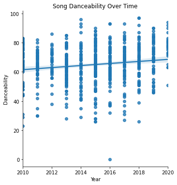

```python
sns.lmplot(x = 'year', y = 'dnce', data = top_all)
plt.title("Song Danceability Over Time")
plt.xlabel("Year")
plt.ylabel("Danceability")
plt.show()
```

From the scatter plot and trend line above, we notice a slight upwards trend in danceability over time from 2010 to 2020.

```python
lm_dnce = smf.ols(formula='dnce ~ year', data = top_all).fit()
print(lm_dnce.summary().tables[0])
print(lm_dnce.summary().tables[1])
```

```
                            OLS Regression Results
==============================================================================
Dep. Variable:                   dnce   R-squared:                       0.021
Model:                            OLS   Adj. R-squared:                  0.020
Method:                 Least Squares   F-statistic:                     14.27
Date:                Mon, 17 May 2021   Prob (F-statistic):           0.000173
Time:                        18:58:55   Log-Likelihood:                -2614.5
No. Observations:                 652   AIC:                             5233.
Df Residuals:                     650   BIC:                             5242.
Df Model:                           1
Covariance Type:            nonrobust
==============================================================================
==============================================================================
                 coef    std err          t      P>|t|      [0.025      0.975]
------------------------------------------------------------------------------
Intercept  -1350.3071    374.726     -3.603      0.000   -2086.126    -614.488
year           0.7024      0.186      3.777      0.000       0.337       1.068
==============================================================================
```

Lastly, we will complete the same steps for song duration.

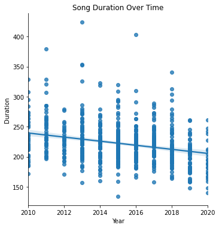

```python
sns.lmplot(x = 'year', y = 'dur', data = top_all)
plt.title("Song Duration Over Time")
plt.xlabel("Year")
plt.ylabel("Duration")
plt.show()
```

Here, we notice some outliers for longer song durations, but we can see a general negative trend on song duration over time from 2010 to 2020.

```python
lm_dur = smf.ols(formula='dur ~ year', data = top_all).fit()
print(lm_dur.summary().tables[0])
print(lm_dur.summary().tables[1])
```

```
                            OLS Regression Results
==============================================================================
Dep. Variable:                    dur   R-squared:                       0.075
Model:                            OLS   Adj. R-squared:                  0.074
Method:                 Least Squares   F-statistic:                     52.88
Date:                Mon, 17 May 2021   Prob (F-statistic):           1.02e-12
Time:                        18:58:56   Log-Likelihood:                -3213.4
No. Observations:                 652   AIC:                             6431.
Df Residuals:                     650   BIC:                             6440.
Df Model:                           1
Covariance Type:            nonrobust
==============================================================================
==============================================================================
                 coef    std err          t      P>|t|      [0.025      0.975]
------------------------------------------------------------------------------
Intercept   7051.2352    939.013      7.509      0.000    5207.369    8895.101
year          -3.3889      0.466     -7.272      0.000      -4.304      -2.474
==============================================================================
```

The summary table above allows us to conclude that on average, for each year increase from 2010 to 2020, the duration of songs decrease by 3.3889 units. This change is at a significant level, although the R-squared value is very low here as well, likely due to the variation and outliers in song duration.

# **6. Insight and Conclusions**

Our purpose for this project was to examine the song elements of the top tracks of 2010-2019 compared to that of the top tracks of 2020 to see if the nature of the COVID-19 pandemic and its effects on society had a discernable impact on popular music. In addition, we wanted to include the role of trending TikTok songs in our project because the platform has added to the capacity for music to go viral and reach popular status.

Next we examined the scatter plots of each property against popularity for the top songs from 2010-2020. Through backwards elimination, we developed a linear regression we found that the track properties of energy, danceability, loudness, and duration are significant in predicting song popularity. We repeated this process to find significant predictors of popularity in TikTok songs, and found that energy, loudness, valence, duration, and speechiness were all significant.

Finally, we examined song energy, danceability, and duration since these properties appeared to have relatively consistent linear trends over the past decade. We found that that the decreases in song energy and duration were indeed significant in addition to the increase in danceability being significant.

Although our regression models showed significant predictors that were linearly correlated with popularity, they also had very low R-squared and Adjusted R-squared values. This may be attributed to the existence of a lot of variation in each song's track property values. Such variation may have been compounded by the fact that we examined TikTok songs and tops songs over a decade that included several genres, likely associated with different music listeners and creators with unique goals, wants, and needs.

To expand on this project in the future, it would be prudent to examine the top songs of specific genres. We would also be interested in exploring if track properties of the top songs during the COVID-19 pandemic had a long term impact in trending music or if the year is made to be an anomaly given the abrupt and major change in circumstances.

If you liked our project, why don't you just *Say So*!

# **7. Resources for Additional Information**

- We drew inspiration from [Kartik Dhawan's personal project](https://towardsdatascience.com/my-quarantine-wrapped-94e5015dc847). It would be a fun to use the knowledge we provided today and analyze your own personal Spotify playlists and see if COVID-19 impacted the music you listened to!
- [Backwards Elimination in data science- a quick read](https://towardsdatascience.com/backward-elimination-for-feature-selection-in-machine-learning-c6a3a8f8cef4)
- [Simple and Multiple Linear Regression in Python](https://towardsdatascience.com/simple-and-multiple-linear-regression-in-python-c928425168f9)